# Data transforms

Jeff Leek

## Dependencies

This document depends on the following packages:

```r
  library(devtools)
  library(Biobase)
  library(dplyr)
```

To install these packages you can use the code (or if you are compiling the document, remove the `eval=FALSE` from the chunk.)

```r
install.packages(c("devtools"))
source("http://www.bioconductor.org/biocLite.R")
biocLite(c("Biobase"))
```

## General principles

- Make sure data is on the right scale for
- Visualization
- Statistical modeling

## Load some data

We will use this expression set to look at how we use plots and tables to check for different characteristics

```r
con =url("http://bowtie-bio.sourceforge.net/recount/ExpressionSets/bodymap_eset.RData")
load(file=con)
close(con)
bm = bodymap.eset
pdata=pData(bm)
edata=as.data.frame(exprs(bm))
fdata = fData(bm)
ls()
```

```
## [1] "bm"           "bodymap.eset" "con"          "edata"
## [5] "fdata"        "pdata"        "tropical"
```

## Skewed distributions

We would like continuous data to be nice and symmetric like a normal distribution for two reasons:(1) plots are easier to see this way and (2) most statistical methods are designed to work better for non-skewed data.

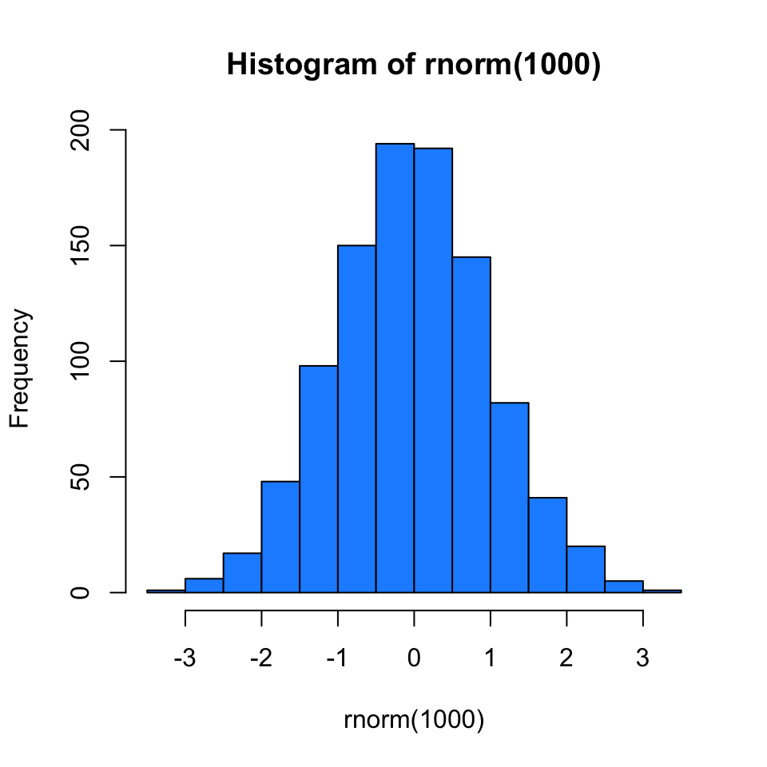

```r
hist(rnorm(1000),col=2)
```

Realistically though most genomic data is skewed

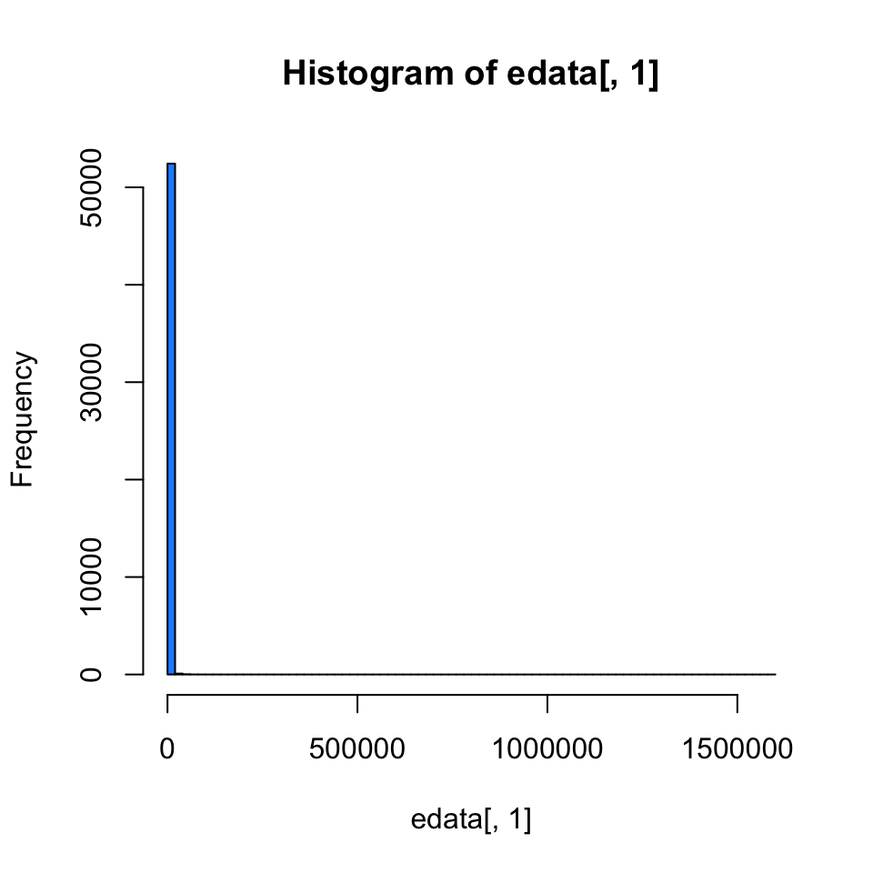

```r
hist(edata[,1],col=2,breaks=100)
```

One way to address this skew is to use a transformation. One common transformation is the `log` transform.

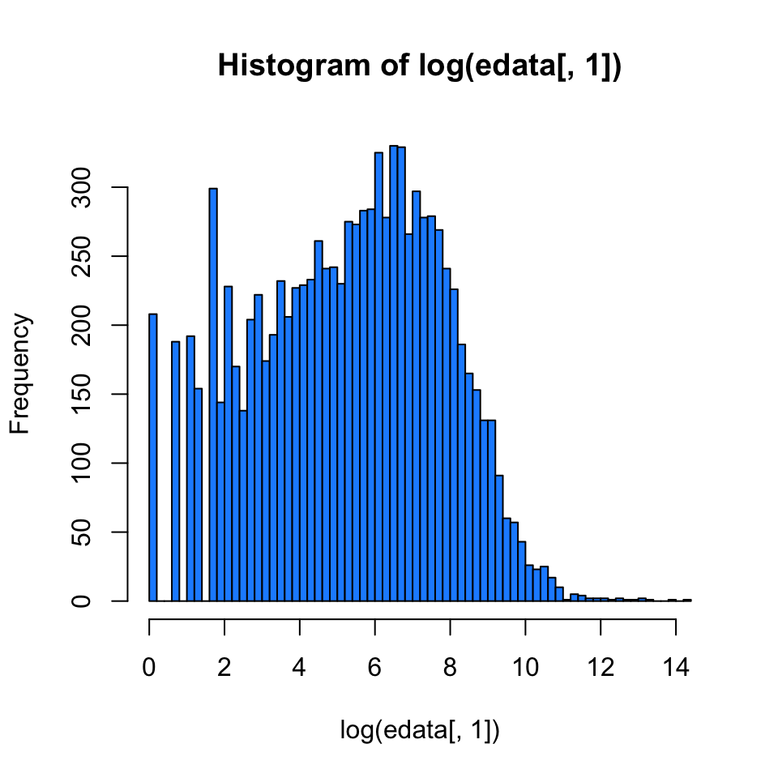

```r
hist(log(edata[,1]),col=2,breaks=100)
```

One thing to be careful with is that values of zero become `-inf` when you apply the log transform because the log of zero isn’t defined.

```r
min(log(edata))
```

```
## [1] -Inf
```

You can remove this problem by adding a small number to all the counts before taking the log. This doesn’t change the overall distribution much but resolves the zero problem

```r
min(log(edata[,1] + 1))
```

```
## [1] 0
```

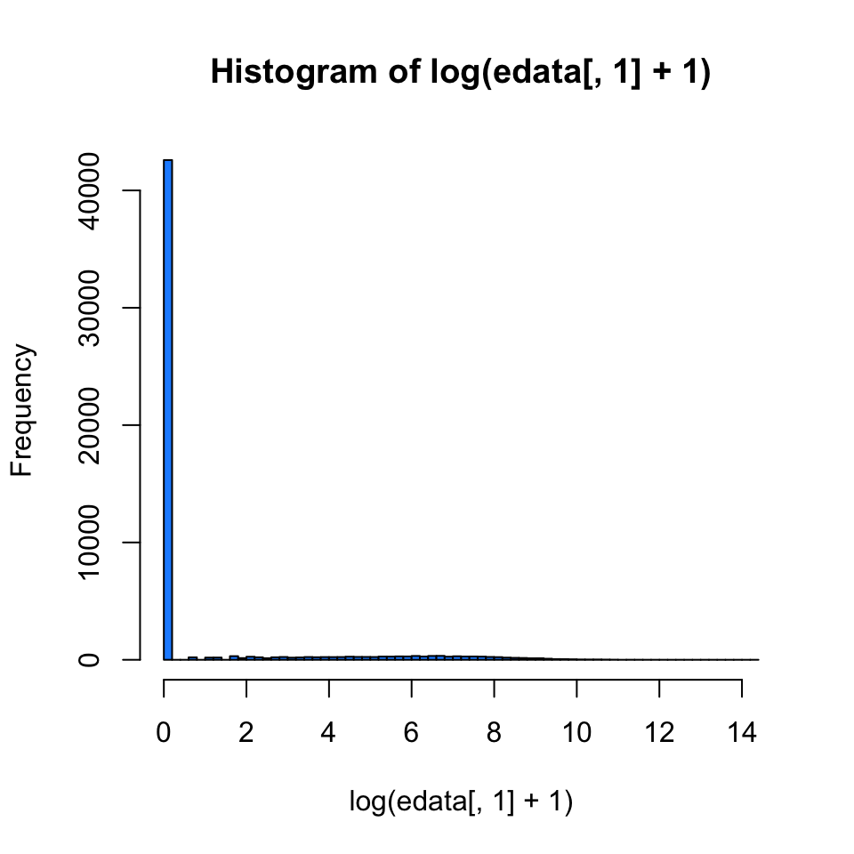

```r
hist(log(edata[,1] + 1),breaks=100,col=2)
```

A common choice is to use the `log2` transform. The reason is that data on the `log2` scale can be expressed as [fold changes](https://en.wikipedia.org/wiki/Fold_change). If `log2(x) - log2(y) = z` then there is a `z` fold change difference between `x` and `y`.

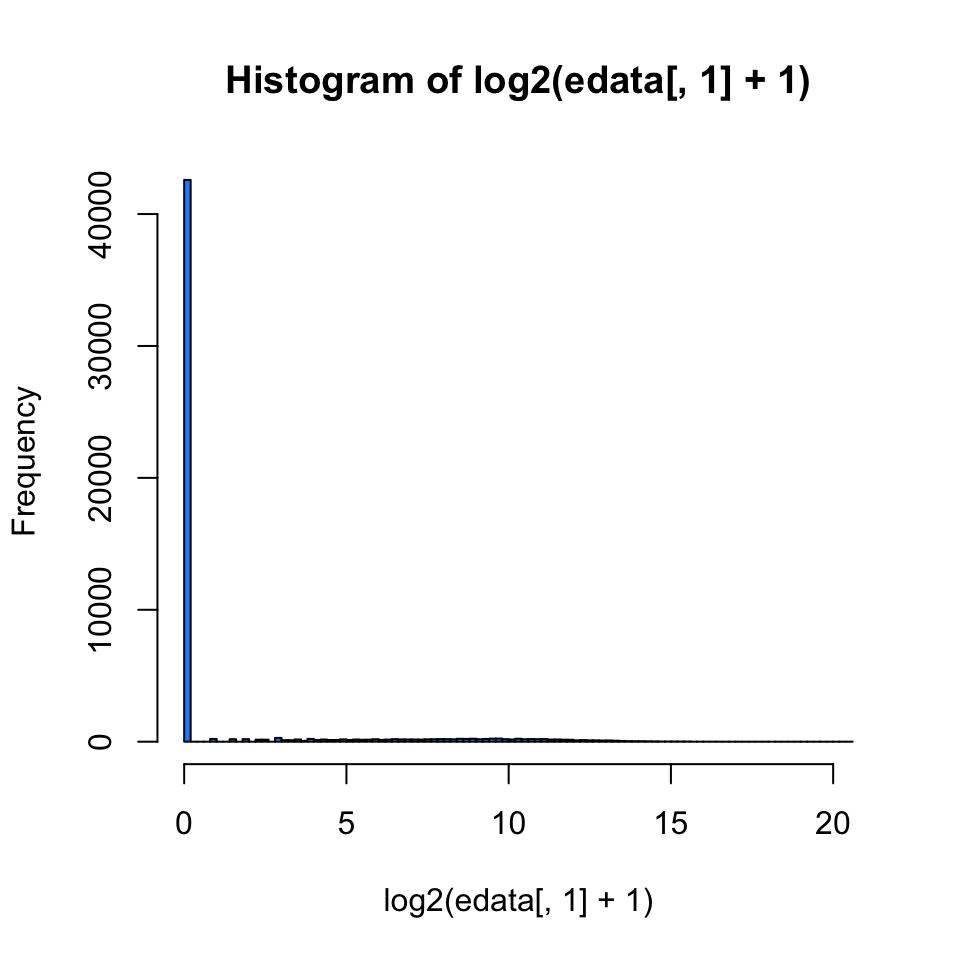

```r
hist(log2(edata[,1] + 1),breaks=100,col=2)
```

Let’s zoom in on the values greater than zero (we’ll come back to the zero values in a minute)

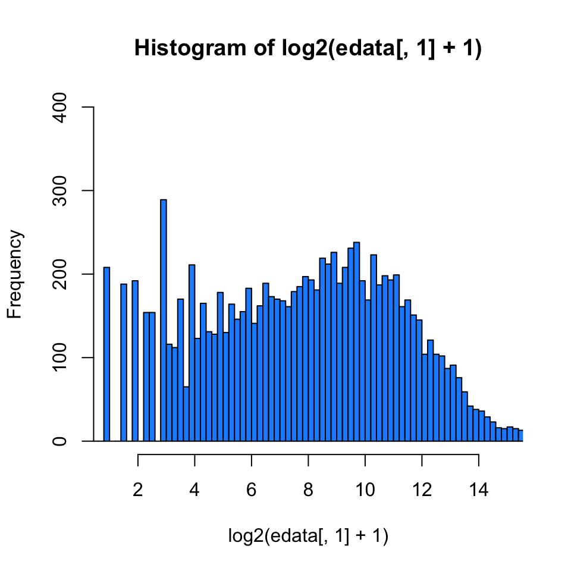

```r
hist(log2(edata[,1] + 1),breaks=100,col=2,xlim=c(1,15),ylim=c(0,400))
```

This is starting to look a little better but we still have the zeros problem.

## Removing features without much data

In many types of sequencing data we observe that there is not much data for many features.

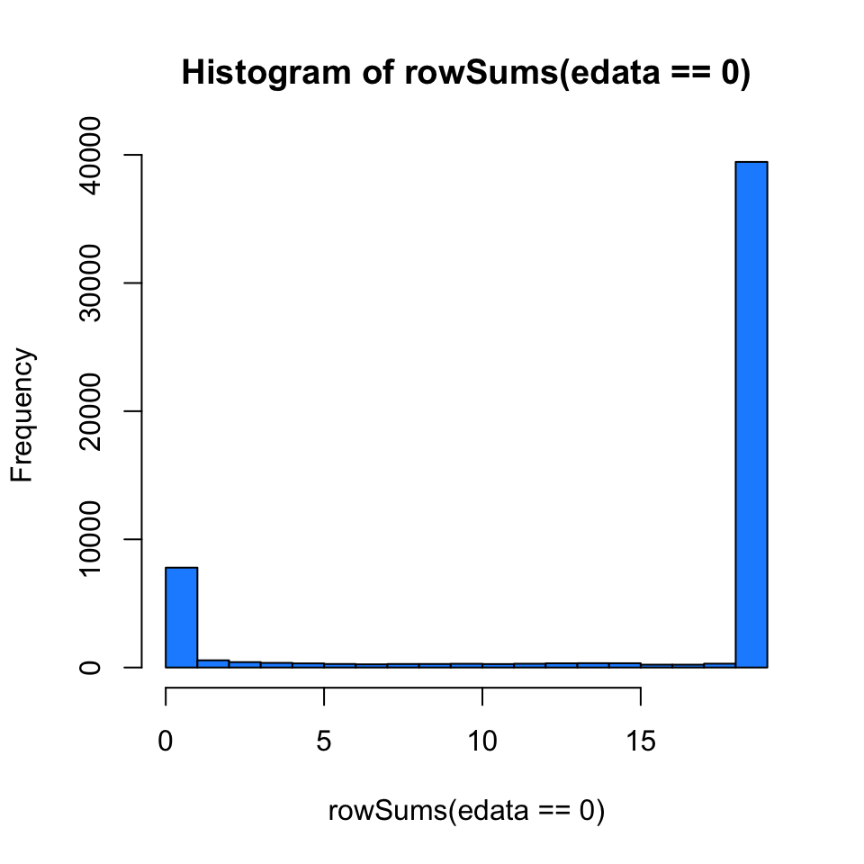

```r
hist(rowSums(edata==0),col=2)
```

A common pre-processing technique is to remove features that don’t have much data. One way to identify and remove them is to use `rowMeans` and `rowMedians`

```r
low_genes = rowMeans(edata) < 5
table(low_genes)
```

```
## low_genes
## FALSE  TRUE
## 11413 41167
```

```r
filt_edata = filter(edata,!low_genes)
dim(filt_edata)
```

```
## [1] 11413    19
```

```r
low_genes2 = rowMedians(as.matrix(edata)) < 5
table(low_genes2,low_genes)
```

```
##           low_genes
## low_genes2 FALSE  TRUE
##      FALSE  9844     2
##      TRUE   1569 41165
```

```r
filt_edata2 = filter(edata,!low_genes2)
dim(filt_edata2)
```

```
## [1] 9846   19
```

After filtering we observe that using the `log` transform makes the distribution much more symmetric but there are still zeros. We could increase the filter to remove this issue if we needed to.

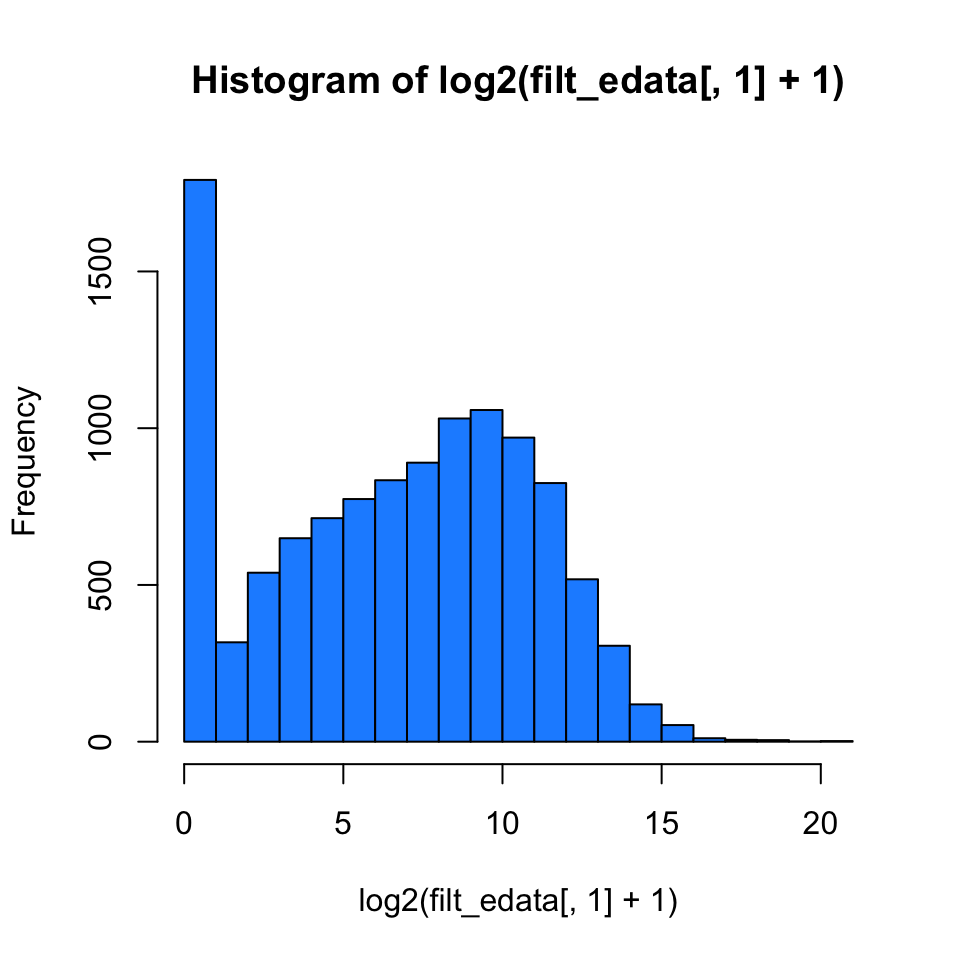

```r
hist(log2(filt_edata[,1] + 1),col=2)
```

## More transforms

There are a large number of other transforms depending on the type of data you are using. Some common ones are:

- [Variance stabilizing transforms](https://en.wikipedia.org/wiki/Variance-stabilizing_transformation) which seek to remove a mean variance relationship among the data
- [Box-Cox transforms](https://en.wikipedia.org/wiki/Power_transform) which seek to make the data approximately Normally distributed
- [rlog transform](http://rpackages.ianhowson.com/bioc/DESeq2/man/rlog.html) - unique to genomics count data, this is a regularized version of the log transform that seeks to minimize differences at low count levels.

## Session information

```
##  setting  value
##  version  R version 3.2.2 (2015-08-14)
##  system   x86_64, darwin13.4.0
##  ui       X11
##  language (EN)
##  collate  en_GB.UTF-8
##  tz       Europe/London
##  date     2015-09-17
##
##  package      * version date       source
##  assertthat     0.1     2013-12-06 CRAN (R 3.2.0)
##  Biobase      * 2.28.0  2015-04-17 Bioconductor
##  BiocGenerics * 0.14.0  2015-04-17 Bioconductor
##  DBI            0.3.1   2014-09-24 CRAN (R 3.2.0)
##  devtools     * 1.9.1   2015-09-11 CRAN (R 3.2.0)
##  digest         0.6.8   2014-12-31 CRAN (R 3.2.0)
##  dplyr        * 0.4.3   2015-09-01 CRAN (R 3.2.2)
##  evaluate       0.7.2   2015-08-13 CRAN (R 3.2.0)
##  formatR        1.2     2015-04-21 CRAN (R 3.2.0)
##  htmltools      0.2.6   2014-09-08 CRAN (R 3.2.0)
##  knitr        * 1.11    2015-08-14 CRAN (R 3.2.2)
##  lazyeval       0.1.10  2015-01-02 CRAN (R 3.2.0)
##  magrittr       1.5     2014-11-22 CRAN (R 3.2.0)
##  memoise        0.2.1   2014-04-22 CRAN (R 3.2.0)
##  R6             2.1.1   2015-08-19 CRAN (R 3.2.2)
##  Rcpp           0.12.1  2015-09-10 CRAN (R 3.2.0)
##  rmarkdown      0.8     2015-08-30 CRAN (R 3.2.2)
##  stringi        0.5-5   2015-06-29 CRAN (R 3.2.0)
##  stringr        1.0.0   2015-04-30 CRAN (R 3.2.0)
##  yaml           2.1.13  2014-06-12 CRAN (R 3.2.0)
```

It is also useful to compile the time the document was processed. This document was processed on: 2015-09-17.